# Identifying Themes from Technical Paper Abstracts

**Prince Joseph Erneszer Javier**  
MSc Data Science  
Asian Institute of Management

## Executive Summary

In this analysis, we identified common themes or topics in academic papers based on paper abstract characteristics. The dataset, containing 500 papers abstracts, titles, and corresponding authors, was prepared by the Access lab from Asian Institute of Management, Philippines. The problem being tackled is identifying the common topics or themes in the corpus of abstracts based on the words used (features). The abstracts were analyzed using two theme-extraction methods: k Means Clustering and Latent Dirichlet Allocation(LDA).

TF-IDF bag of words vectorization with Euclidean normalization was applied on the corpus of abstracts. Words that occur in less than 10% of the documents were dropped, as well as those that occur in more than 50% of the documents. This was done because the rarest and most common words do not contribute to new information about the themes in the abstracts. For similar reasons, common english words were also removed from the abstracts.

Principal Component Analysis (PCA) was used to inspect visually the clusters generated by k Means and LDA on the abstracts. The abstract TF-IDF vectors were projected on the first two principal components (2D plot) and first three principal components (3D plot).

k Means clustering was able to form clear boundaries between clusters for two clusters or three clusters. Beyond this, overlaps between clusters form. This means that two or three clusters is preferrable to distinguish the groups clearly. When three clusters were used for LDA however, two clusters overlap. For LDA, two clusters was found to clearly separate abstracts. The table below shows the top words in each theme for each clustering method.

[output not shown]

Although k Means was able to generate two or three separate clusters, as projected on the principal components, the clusters are more difficult to interpret and some top words overlap. For k=3 we can infer that one cluster is about time-related problems, but the other two clusters are more vague. LDA, on the other hand was able to identify networks as a clear theme, and the other is about time, similar to what k means identified.

k Means and LDA can be used to cluster technical paper abstracts. It is recommended to use LDA since it was able to show distinctly two separate themes namely, 1) time, problem, function and 2) network, networks, learning.

## Data Description

The dataset was prepared by data scientists from The Asian Institute of Management Access Lab. The dataset contains information about 500 research papers. The information are:

1. title - title of the paper
2. abstract - abstract of the paper
3. date created - date the paper was created
4. authors - authors of the paper

## Python Packages

`Numpy` gives a wide array of functionality when dealing with arrays (pun intended). `Matplotlib` allows us to make charts easily. `Pandas` enables us to transform data into tables that are more understandable and transformable. `Counter` enables us to quickly count unique elements in a sequence like a dictionary.

Six packages were imported from `Scikit-learn`, which contains many machine learning algorithms. `ENGLISH_STOP_WORDS` imports words that are most commonly used in English like "the", "of", and "for", so they can be removed from the analysis as they don't add useful information. `CountVectorizer` converts a text into a Bag-of-Words vector with values corresponding to the counts of each word. `TfidfVectorizer` works the same way except that the values in the bag of words vectors are in a way "regularized", reducing values of least important words and increasing values of more important words.

`PCA`, referring to principal component analysis, is a package that allows quick computation of principal components, which in the simplest of terms is like viewing a camera at an object and finding the angle that best identifies the object. `KMeans` is used to perform clustering based on how similar the elements or vectors are. Every element in KMeans is clustered into one unique cluster. `LatentDirichletAllocation`, meanwhile, can be used to cluster bag of words vectors based on how frequently words appear together, while at the same time acknowledging that each vector or document can have multiple topics or clusters (in contrast to k Means).

```python
import numpy as np
import matplotlib.pyplot as plt
from mpl_toolkits.mplot3d import Axes3D
%matplotlib inline
import pandas as pd
from collections import Counter

from sklearn.feature_extraction.text import ENGLISH_STOP_WORDS
from sklearn.feature_extraction.text import CountVectorizer
from sklearn.feature_extraction.text import TfidfVectorizer

from sklearn.decomposition import PCA
from sklearn.cluster import KMeans
from sklearn.decomposition import LatentDirichletAllocation
```

## Exploratory Data Analysis

### Importing Data

The dataset is saved in a comma-separated values (csv) file `arxiv-collection.csv`. The dataset was loaded in a pandas dataframe, `_df`, which organizes the data in table form.

The dataset contains 5 columns: `Unnamed: 0`, `title`, `abstract`, `created`, and `authors`. Upon further inspection, we see that `Unnamed: 0` is just the index of the row, and so was dropped during data cleaning.

```python
_df = pd.read_csv('arxiv-collection.csv')
_df.reset_index()
print("No. of features/columns in the dataset: {}".format(_df.shape[1]))
print("No. of samples/rows in the dataset: {}".format(_df.shape[0]))
print("Columns: {}".format(_df.columns))
```

```
No. of features/columns in the dataset: 5
No. of samples/rows in the dataset: 500
Columns: Index(['Unnamed: 0', 'title', 'abstract', 'created', 'authors'], dtype='object')
```

```python
print("Top 3 rows in Unnamed: 0:\n{}".format(_df['Unnamed: 0'].head(3)))
print("Top 3 rows in Unnamed: 0:\n{}".format(_df['Unnamed: 0'].tail(3)))
```

```
Top 3 rows in Unnamed: 0:
0    0
1    1
2    2
Name: Unnamed: 0, dtype: int64
Top 3 rows in Unnamed: 0:
497    497
498    498
499    499
Name: Unnamed: 0, dtype: int64
```

### Cleaning the Data

There are no null values in the dataset.

```python
_df.info()

print()
a = np.sum([_df.isnull().any()])

print("No. of columns with null: {}".format(a))
print("===========")
```

```
<class 'pandas.core.frame.DataFrame'>
RangeIndex: 500 entries, 0 to 499
Data columns (total 5 columns):
Unnamed: 0    500 non-null int64
title         500 non-null object
abstract      500 non-null object
created       500 non-null object
authors       500 non-null object
dtypes: int64(1), object(4)
memory usage: 19.6+ KB

No. of columns with null: 0
===========
```

`Unnamed: 0` only contains indices of the rows in the dataset. We dropped this column and save the new dataset in `df`.

```python
df = _df.drop('Unnamed: 0', axis=1)
print("No. of features/columns in the dataset: {}".format(df.shape[1]))
print("No. of samples/rows in the dataset: {}".format(df.shape[0]))
print("Columns: {}".format(df.columns))
```

```
No. of features/columns in the dataset: 4
No. of samples/rows in the dataset: 500
Columns: Index(['title', 'abstract', 'created', 'authors'], dtype='object')
```

There are only 490 unique abstracts in the dataset, and redundant abstracts need to be removed. We saved the new corpus of abstracts into a list `abstracts`.

```python
print("Number of unique abstracts in dataset:", len(set(df.abstract)))
abstracts = list(set(df.abstract))
```

```
Number of unique abstracts in dataset: 490
```

Similarly, there are only 490 unique abstracts in the dataset, and redundant abstracts need to be removed. We saved the new corpus of abstracts into a list `titles`.

```python
print("Number of unique titles in dataset:", len(set(df.title)))
titles = list(set(df.title))
```

```
Number of unique titles in dataset: 490
```

### Exploring the Data

We convert the titles and the abstracts into bag-of-words (BoW) vector representation saved to `bow_title`. When converting to BoW, we remove commonly used English words like "and", "or", and "the" by applying `stop_words`="english". The corpus of titles contain 1754 words and 490 titles.

```python
# Converting titles to BoW vector representation
w = titles
vect_title = CountVectorizer(stop_words='english').fit(w)
bow_title = vect_title.transform(w)
print("No. of words considered in corpus:", len(vect_title.vocabulary_))
print("No. of documents converted to BoW vectos:",
      (bow_title.toarray().shape[0]))
print("Length of each BoW vector:", (bow_title.toarray().shape[1]))
```

```
No. of words considered in corpus: 1754
No. of documents converted to BoW vectos: 490
Length of each BoW vector: 1754
```

There are 490 titles in the dataset. Below are the top ten most common words in the title identified after preprocessing the data.

|  | Word | Count |
| --- | --- | --- |
| 0 | learning | 61 |
| 1 | networks | 55 |
| 2 | using | 48 |
| 3 | network | 40 |
| 4 | deep | 39 |
| 5 | data | 35 |
| 6 | based | 29 |
| 7 | analysis | 28 |
| 8 | neural | 27 |
| 9 | model | 26 |

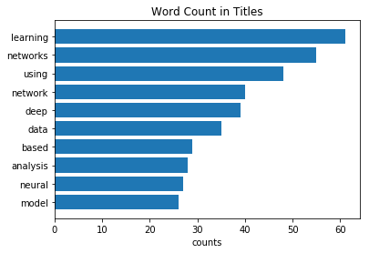

```python
counts = np.array((bow_title.sum(axis=0)).tolist()[0])
inds = np.argsort(counts)[::-1]
feats = np.array(vect_title.get_feature_names())
a = pd.Series(feats[inds], name='Word')
b = pd.Series(counts[inds], name='Count')
c = pd.concat([a, b], axis=1)
display(c.head(10))

plt.barh(sorted(a[:10]), sorted(b[:10]))
plt.yticks(np.arange(10), a[:10][::-1])
plt.title('Word Count in Titles')
plt.xlabel('counts')
plt.show()
```

We converted the abstracts into BoW, again removing commonly used words. The corpus of abstracts contain 7602 words and 490 abstracts.

```python
# Converting abstracts to BoW vector representation
w = abstracts
vect_title = CountVectorizer(stop_words='english').fit(w)
bow_title = vect_title.transform(w)
print("No. of words considered in corpus:", len(vect_title.vocabulary_))
print("No. of documents converted to BoW vectos:",
      (bow_title.toarray().shape[0]))
print("Length of each BoW vector:", (bow_title.toarray().shape[1]))
```

```
No. of words considered in corpus: 7602
No. of documents converted to BoW vectos: 490
Length of each BoW vector: 7602
```

Below are the most used words in the abstract.

|  | Word | Count |
| --- | --- | --- |
| 0 | model | 367 |
| 1 | data | 354 |
| 2 | network | 288 |
| 3 | networks | 287 |
| 4 | method | 249 |
| 5 | based | 242 |
| 6 | results | 219 |
| 7 | learning | 215 |
| 8 | using | 204 |
| 9 | time | 203 |

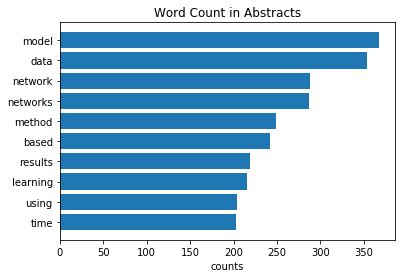

```python
counts = np.array((bow_title.sum(axis=0)).tolist()[0])
inds = np.argsort(counts)[::-1]
feats = np.array(vect_title.get_feature_names())
a = pd.Series(feats[inds], name='Word')
b = pd.Series(counts[inds], name='Count')
c = pd.concat([a, b], axis=1)
display(c.head(10))

plt.barh(sorted(a[:10]), sorted(b[:10]))
plt.yticks(np.arange(10), a[:10][::-1])
plt.title('Word Count in Abstracts')
plt.xlabel('counts')
plt.show()
```

```python
print("Title of paper in 1st row: {}\n".format(df.title[0]))
print("Abstract of paper in 1st row: {}\n".format(abstracts[0]))
print("Date Paper in 1st row was created: {}\n".format(df.created[0]))
print("Authors of paper in 1st: {}\n".format(df.authors[0]))
```

```
Title of paper in 1st row: designing random graph models using variational autoencoders with   applications to chemical design

Abstract of paper in 1st row: some recent works revealed that deep neural networks (dnns) are vulnerable to so-called adversarial attacks where input examples are intentionally perturbed to fool dnns. in this work, we revisit the dnn training process that includes adversarial examples into the train…

Date Paper in 1st row was created: 2018-02-14

Authors of paper in 1st: ['samanta', 'de', 'ganguly', 'gomez-rodriguez']
```

## Models

### Converting to BoW with TF-IDF

Aside from converting text into a bag-of-words vector (BoW) by counts, another method is by getting the term frequency-inverse document frequency (TF-IDF) values. Simply put, the counts (term frequency) are multiplied by a factor that reduces the value of common, uninformative words based on how many documents contain those words. The equation is:

\begin{equation} TFIDF = TF \times log \left(\frac{N+1}{N_w+1}\right)+1 \end{equation}

Where, $TF$ is the term frequency, $N$ is the total number of documents in the corpus, and $N_w$ is the number of documents containing the word $w$.

In this paper, `Scikit-learn`'s `TfidfVectorizer` package was used. The words that occur in less than 10% of the documents were removed as well as those that occur in more than 50% of the documents, to eliminate more non-value adding words.

### K Means Clustering

K Means Clustering is used to cluster unlabeled datapoints based on the similarity of their features. The parameter k, corresponds to the number of clusters that will be generated.

The abstracts were first converted into BoW vectors using Tfidf vectorizer. As mentioned above, words that occur in less than 10% of the documents or more than 50% of the documents were dropped, "stop words" or common English words like "the", "and", or "or" were also dropped.

Afterwards, k Means clustering was applied for 2, 3, 4, and 5 clusters. The findings are discussed and visualized below.

##### 2 Clusters

Because of the removal of the most common words, the number of elements in the BoW vector was reduced to 79. This value is consistent for all models used here.

```python
def clustering(docs, clusters=2):
    vect = TfidfVectorizer(min_df=0.1, max_df=0.5, stop_words="english")
    X = vect.fit_transform(docs)
    kmeans = KMeans(n_clusters=clusters, max_iter=500).fit(X)
    # kmeans.labels_

    big_inds = []
    for c in range(clusters):
        small_inds = [i for i in range(
            len(kmeans.labels_)) if kmeans.labels_[i] == c]
        big_inds.append(small_inds)

    clustered_docs = []
    for i in range(clusters):
        cluster_inds = big_inds[i]
        small_docs = np.array(docs)[cluster_inds]
        clustered_docs.append(small_docs)

    print("No. of clusters:", clusters)
    print("No. of words:", len(vect.get_feature_names()))

    return kmeans, clustered_docs

clusters = 2
kmeans, clustered_abs = clustering(abstracts, clusters)
```

```
No. of clusters: 2
No. of words: 79
```

The most important words in the abstracts per theme or cluster are shown below.

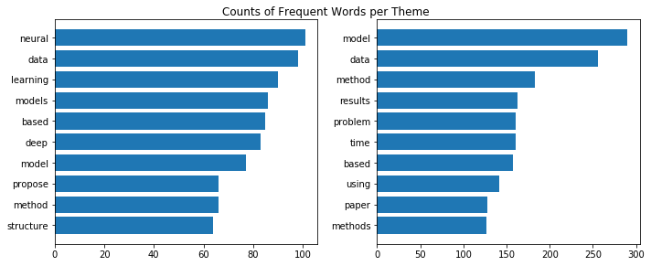

|  | Theme 0 | Counts 0 | Theme 1 | Counts 1 |
| --- | --- | --- | --- | --- |
| 0 | neural | 101 | model | 290.0 |
| 1 | data | 98 | data | 256.0 |
| 2 | learning | 90 | method | 183.0 |
| 3 | models | 86 | results | 163.0 |
| 4 | based | 85 | problem | 161.0 |
| 5 | deep | 83 | time | 161.0 |
| 6 | model | 77 | based | 157.0 |
| 7 | propose | 66 | using | 141.0 |
| 8 | method | 66 | paper | 128.0 |
| 9 | structure | 64 | methods | 127.0 |

```python
# Showing most frequent words per cluster
def themes_knn(clustered_docs, clusters=2):
    """
    Imput
    =====
    clusters: Int. Number of clusters
    clustered_docs: List of lists of clustered docs

    Outpu
    =====
    Dataframe of most common words per cluster.
    Bar chart of most common words per cluster
    """
    cv = CountVectorizer(min_df=0.1, max_df=0.5, stop_words="english")
    df_0 = pd.DataFrame()
    max_vals = []

    for i in range(clusters):
        cv_fit = cv.fit_transform(clustered_docs[i])
        feature_names = np.array(cv.get_feature_names())

        vals = cv_fit.toarray().sum(axis=0)  # get total count per word
        sorting = np.argsort(vals)[::-1]
        # Highest Counts

        s = pd.Series(feature_names[sorting])
        c = pd.Series(vals[sorting])
        df_0['Theme ' + str(i)] = s
        df_0['Counts ' + str(i)] = c

        max_vals.append(vals[sorting])

    plt.figure(figsize=(10, 4))
    for i in range(clusters):
        plt.subplot(1, clusters, i + 1)
        x = df_0.iloc[:, 2*i][:10]
        y = max_vals[i][:10]
        plt.yticks(np.arange(10), x[::-1])
        plt.barh(sorted(x), sorted(y))

    plt.suptitle('Counts of Frequent Words per Theme', y=1)
    plt.tight_layout()
    plt.show()

    return df_0


df = themes_knn(clustered_abs, clusters)
display(df.head(10))
```

The number of abstracts contained in each theme or cluster are shown below.

```python
for i in range(clusters):
    print("Abstracts with Theme {}: {}".format(i,len(clustered_abs[i])))
```

```
Abstracts with Theme 0: 143
Abstracts with Theme 1: 347
```

Principal component analysis was performed to find the top three components that explain the most information (variance). Plotting the variance explained (information) vs the nth principal component, we observe that the top three principal components explain the most information.

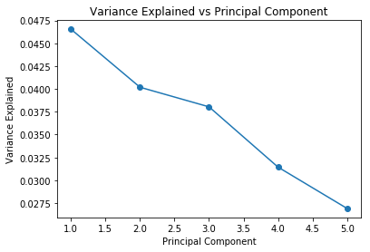

```python
comps = 5

vect = TfidfVectorizer(min_df=0.1, max_df=0.8, stop_words="english")
X = vect.fit_transform(abstracts)
pca = PCA(n_components=comps)
pca.fit(X.toarray())
X = pca.transform(X.toarray())
y_ = pca.explained_variance_ratio_
plt.plot(range(1, comps + 1), y_, marker='o')
plt.xlabel('Principal Component')
plt.ylabel('Variance Explained')
plt.title('Variance Explained vs Principal Component')
plt.show()
```

To visualize the separation of clusters, the clusters were projected on the top three principal components on a 3D plot, and the top two principal components on the 2D plot. From the plot below, we can see that the clusters are segregated.

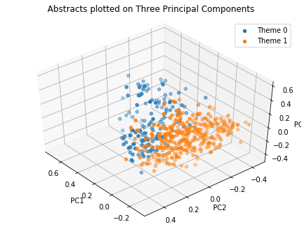

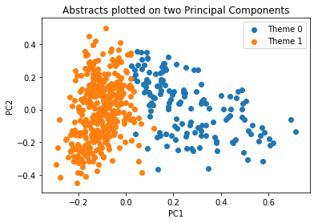

```python
def plot_knn(kmeans, clusters):
    fig = plt.figure(1)
    ax = Axes3D(fig, rect=[0, 0, .95, 1], elev=45, azim=140)

    for i in range(clusters):
        ax.scatter(X[kmeans.labels_ == i, 0], X[kmeans.labels_ == i, 1],
                   X[kmeans.labels_ == i, 2], label='Theme ' + str(i))

    ax.set_title('Abstracts plotted on Three Principal Components\n\n')
    ax.set_xlabel('PC1')
    ax.set_ylabel('PC2')
    ax.set_zlabel('PC3')

    ax.legend()
    plt.show()

    fig = plt.figure()

    for i in range(clusters):
        plt.scatter(X[kmeans.labels_ == i, 0], X[kmeans.labels_ == i, 1],
                   label = 'Theme '+str(i))
        plt.title('Abstracts plotted on two Principal Components')
        plt.xlabel('PC1')
        plt.ylabel('PC2')
        plt.legend()
    plt.show()

plot_knn(kmeans, clusters)
```

##### 3 Clusters

The most important words in the abstracts per theme or cluster are shown below.

```
No. of clusters: 3
No. of words: 79
```

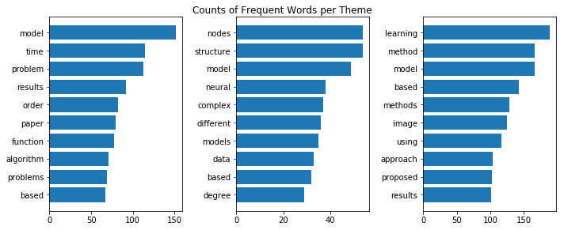

|  | Theme 0 | Counts 0 | Theme 1 | Counts 1 | Theme 2 | Counts 2 |
| --- | --- | --- | --- | --- | --- | --- |
| 0 | model | 152 | nodes | 54 | learning | 189 |
| 1 | time | 115 | structure | 54 | method | 167 |
| 2 | problem | 113 | model | 49 | model | 166 |
| 3 | results | 92 | neural | 38 | based | 143 |
| 4 | order | 82 | complex | 37 | methods | 129 |
| 5 | paper | 79 | different | 36 | image | 125 |
| 6 | function | 78 | models | 35 | using | 117 |
| 7 | algorithm | 71 | data | 33 | approach | 104 |
| 8 | problems | 69 | based | 32 | proposed | 102 |
| 9 | based | 67 | degree | 29 | results | 101 |

```python
clusters = 3
kmeans, clustered_abs = clustering(abstracts, clusters);

# Showing most frequent words per cluster
df = themes_knn(clustered_abs, clusters)
display(df.head(10))
```

One theme might be about time-related problems, another might be about methods for image-related problems, and the other might be about neural networks. The number of abstracts contained in each theme or cluster are shown below.

```python
for i in range(clusters):
    print("Abstracts with Theme {}: {}".format(i,len(clustered_abs[i])))
```

```
Abstracts with Theme 0: 207
Abstracts with Theme 1: 78
Abstracts with Theme 2: 205
```

To visualize the separation of clusters, the clusters were projected on the top three principal components on a 3D plot, and the top two principal components on the 2D plot. We can see that the clusters are separate.

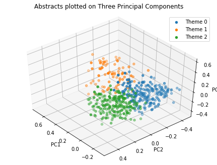

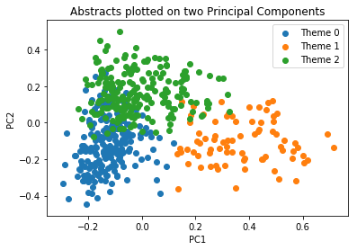

```python
plot_knn(kmeans, clusters)
```

##### 4 Clusters

The most important words in the abstracts per theme or cluster are shown below.

```
No. of clusters: 4
No. of words: 79
```

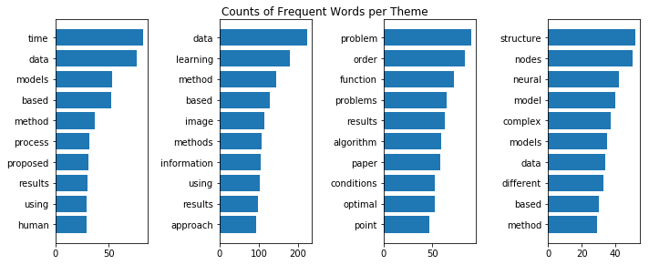

|  | Theme 0 | Counts 0 | Theme 1 | Counts 1 | Theme 2 | Counts 2 | Theme 3 | Counts 3 |
| --- | --- | --- | --- | --- | --- | --- | --- | --- |
| 0 | time | 82 | data | 223 | problem | 90.0 | structure | 52 |
| 1 | data | 76 | learning | 179 | order | 83.0 | nodes | 50 |
| 2 | models | 53 | method | 145 | function | 72.0 | neural | 42 |
| 3 | based | 52 | based | 128 | problems | 65.0 | model | 40 |
| 4 | method | 37 | image | 114 | results | 63.0 | complex | 37 |
| 5 | process | 32 | methods | 108 | algorithm | 59.0 | models | 35 |
| 6 | proposed | 31 | information | 104 | paper | 58.0 | data | 34 |
| 7 | results | 30 | using | 103 | conditions | 52.0 | different | 33 |
| 8 | using | 29 | results | 99 | optimal | 52.0 | based | 30 |
| 9 | human | 29 | approach | 94 | point | 47.0 | method | 29 |

```python
clusters = 4
kmeans, clustered_abs = clustering(abstracts, clusters);

# Showing most frequent words per cluster
df = themes_knn(clustered_abs, clusters)
display(df.head(10))
```

The number of abstracts contained in each theme or cluster are shown below.

```python
for i in range(clusters):
    print("Abstracts with Theme {}: {}".format(i,len(clustered_abs[i])))
```

```
Abstracts with Theme 0: 88
Abstracts with Theme 1: 191
Abstracts with Theme 2: 135
Abstracts with Theme 3: 76
```

To visualize the separation of clusters, the clusters were projected on the top three principal components on a 3D plot, and the top two principal components on the 2D plot. Immediately, we see that there is an overlap between two of the themes.

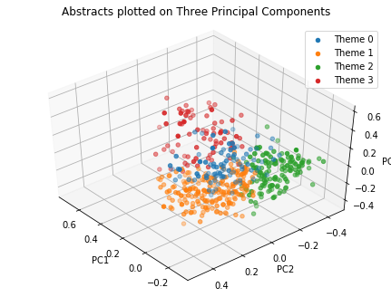

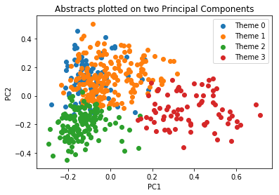

```python
plot_knn(kmeans, clusters)
```

##### 5 Clusters

Finally, we plot the data using five clusters. The charts below show multiple overlaps between clusters.

```
No. of clusters: 5
No. of words: 79
```

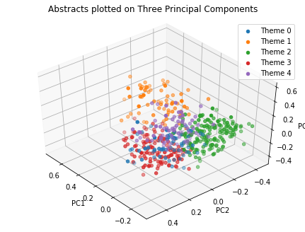

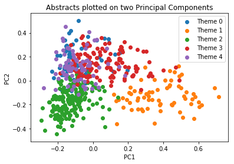

```python
clusters = 5
kmeans, clustered_abs = clustering(abstracts, clusters);
plot_knn(kmeans, clusters)
```

Based on the plots on the principal components above, clustering into two or three clusters results in well segregated clusters, while clustering into four or five results in multiple overlaps between clusters. Below are the first two sentences in five abstracts belonging to each of the three clusters, using k=3.

```python
# First five abstracts in Topics
clusters = 3
kmeans, clustered_abs = clustering(abstracts, clusters);
for i in range(clusters):
    num = 1
    print("Theme", i)
    print("=====================")
    for a in clustered_abs[i][:5]:
        print(num, ".".join(a.split(".")[:2]) + "\n")
        num += 1
```

```
No. of clusters: 3
No. of words: 79
Theme 0
=====================
1 the goal of this paper is to present two algorithms for solving systems of inclusion problems, with all component of the systems being a sum of two maximal monotone operators. the algorithms are variants of the forward-backward splitting method and one being a hybrid with the alternating projectio…

2 we provide a compactness criterion for the set of laws $\mathfrak{p}^{ac}_{sem}(\theta)$ on the skorokhod space for which the canonical process $x$ is a semimartingale having absolutely continuous characteristics with differential characteristics taking values in some given set $\theta$ of l\'evy …

3 we consider the minimization of a cost function $f$ on a manifold $m$ using riemannian gradient descent and riemannian trust regions (rtr). we focus on satisfying necessary optimality conditions within a tolerance $\varepsilon$

4 this paper considers optimization over multiple renewal systems coupled by time average constraints. these systems act asynchronously over variable length frames

5 we construct subgame-perfect equilibria with mixed strategies for symmetric stochastic timing games with arbitrary strategic incentives. the strategies are qualitatively different for local first- or second-mover advantages, which we analyse in turn

Theme 1
=====================
1 we introduce a family of unsupervised domain-free and (asymptotically) model-independent algorithms based on algorithmic information theory designed to minimize the loss of any (enumerable computable) property contributing to the object's algorithmic content and thus important to preserve in the p…

2 finding graph indices which are unbiased to network size is of high importance both within a given field and across fields for enhancing comparability over the cornucopia of modern network science studies. this is also important within studies for comparability of subnetworks within a given networ…

3 we propose a statistical mechanics approach to a coevolving spin system with an adaptive network of interactions. the dynamics of node states and network connections is driven by both spin configuration and network topology

4 in the domain of sequence modelling, recurrent neural networks (rnn) have been capable of achieving impressive results in a variety of application areas including visual question answering, part-of-speech tagging and machine translation. however this success in modelling short term dependencies ha…

5 the emergence of large-scale connectivity underlies the proper functioning of many networked systems, ranging from social networks and technological infrastructure to global trade networks. percolation theory characterizes network formation following stochastic local rules, while optimization mode…

Theme 2
=====================
1 some recent works revealed that deep neural networks (dnns) are vulnerable to so-called adversarial attacks where input examples are intentionally perturbed to fool dnns. in this work, we revisit the dnn training process that includes adversarial examples into the training dataset so as to improve…

2 several experiments in high-energy physics and astrophysics can be treated as on/off measurements, where an observation potentially containing a new source or effect ("on" measurement) is contrasted with a background-only observation free of the effect ("off" measurement). in counting experiments,…

3 modeling and verifying real-world cyber-physical systems is challenging, which is especially so for complex systems where manually modeling is infeasible. in this work, we report our experience on combining model learning and abstraction refinement to analyze a challenging system, i

4 we present a probabilistic model of an intrusion in a renewal process. given a process and a sequence of events, an intrusion is a subsequence of events that is not produced by the process

5 learning tasks on source code (i.e
```

### Latent Dirichlet Allocation

Latent Dirichlet Allocation (LDA) is an algorithm that can be used to extract themes from a set of documents. LDA can be used to calculate the probability that a document belongs to a particular group given the set of words it contains. Unlike k Means classifier, however, LDA considers the fact that a document may have multiple topics, so boundaries between "clusters" or themes are "fuzzy" and not as clear cut as kNN. Instead LDA gives the probabilities that a document belongs to a certain cluster.

Similar to what was done when clustering using kMeans, abstracts were first converted to TfIdf bag of words. These vectors were then fed into `Scikit-learn`'s LDA package. Again, words occurring in less than 10% of the documents or more than 50% of the documents were dropped. Common english words were also removed.

LDA was run on 3 and 2 clusters. The results are discussed and visualized below.

##### 3 Clusters

```python
def run_lda(clusters, docs):
    vect = TfidfVectorizer(min_df=0.1, max_df=0.5, stop_words="english")
    X = vect.fit_transform(docs)
    lda = LatentDirichletAllocation(
        n_components=clusters, learning_method='batch', max_iter=100,
        random_state=42)
    docs_topics = lda.fit_transform(X)

    print("Number of clusters:", lda.components_.shape[0])
    print("Number of words:", lda.components_.shape[1])

    return vect, lda, docs_topics

clusters = 3
vect, lda, abstract_topics = run_lda(clusters, abstracts)
```

```
Number of clusters: 3
Number of words: 79
```

```python
def themes_lda(vect, lda):
    """
    Imput
    =====
    vect: bag of words vectorizer function (Counts/Tfidf)
    lda: latent Dirichlet Allocation function

    Output
    =====
    Dataframe of most common words per cluster.
    """
    feature_names = np.array(vect.get_feature_names())
    sorts = np.argsort(lda.components_, axis=1)[:, ::-1]
    df_0 = pd.DataFrame()
    for i in range(len(sorts)):
        s = pd.Series(feature_names[sorts[i]])
        df_0['Theme ' + str(i)] = s
    return df_0

display(themes_lda(vect, lda).head(10))
```

|  | Theme 0 | Theme 1 | Theme 2 |
| --- | --- | --- | --- |
| 0 | problem | model | learning |
| 1 | function | network | image |
| 2 | algorithm | networks | data |
| 3 | algorithms | analysis | method |
| 4 | point | data | approach |
| 5 | problems | time | methods |
| 6 | optimal | systems | based |
| 7 | optimization | information | neural |
| 8 | local | structure | performance |
| 9 | solution | properties | deep |

Principal component analysis was performed to find the top three components that explain the most information (variance). To visualize the separation of clusters, the clusters were projected on the top three principal components on a 3D plot, and the top two principal components on the 2D plot.

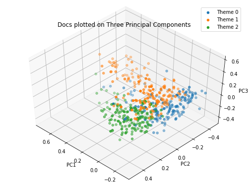

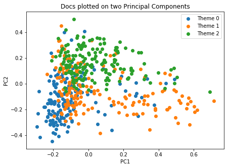

```python
# Cluster labeling
def plot_lda(docs, docs_topics, clusters):
    labels = [0]*len(docs)
    for c in range(clusters):
        theme = np.argsort(docs_topics[:, c])[::-1]
        for i in theme[:int(len(docs)/clusters)]:
            labels[i] = c

    comps=3
    vect = TfidfVectorizer(min_df=0.1, max_df=0.5, stop_words="english")
    X = vect.fit_transform(docs)
    pca = PCA(n_components=comps)
    pca.fit(X.toarray())
    X = pca.transform(X.toarray())

    fig = plt.figure(1, figsize=(7, 5))
    ax = Axes3D(fig, rect=[0, 0, .95, 1], elev=48, azim=134)

    for i in range(clusters):
        inds = [w for w in range(len(labels)) if labels[w] == i]
        ax.scatter(X[inds, 0], X[inds, 1], X[inds, 2], label='Theme ' + str(i))

        ax.set_title('Docs plotted on Three Principal Components\n\n')
        ax.set_xlabel('PC1')
        ax.set_ylabel('PC2')
        ax.set_zlabel('PC3')

    ax.legend()
    plt.show()

    fig = plt.figure(1, figsize=(7, 5))

    for i in range(clusters):
        inds = [w for w in range(len(labels)) if labels[w] == i]
        color = np.argsort(docs_topics[:, c])[::-1][:len(inds)]
        #cmaps = ['Blues', 'Oranges', 'Greens']
        plt.scatter(X[inds, 0], X[inds, 1], label='Theme ' + str(i))
        plt.title('Docs plotted on two Principal Components')
        plt.xlabel('PC1')
        plt.ylabel('PC2')
        plt.legend()

    plt.show()

plot_lda(abstracts, abstract_topics, clusters)
```

The charts above show that there is some overlap between two of the themes identified.

##### 2 Clusters

```python
clusters = 2
vect, lda, abstract_topics = run_lda(clusters, abstracts)
```

```
Number of clusters: 2
Number of words: 79
```

Running LDA with two clusters produces a clearer boundary between the two clusters as shown in the charts below.

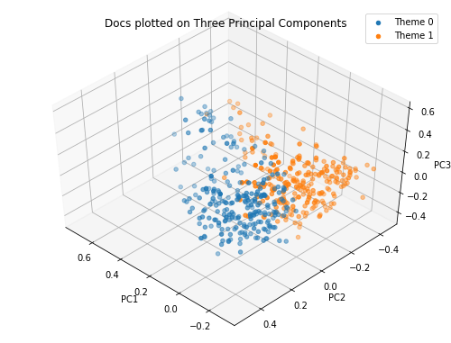

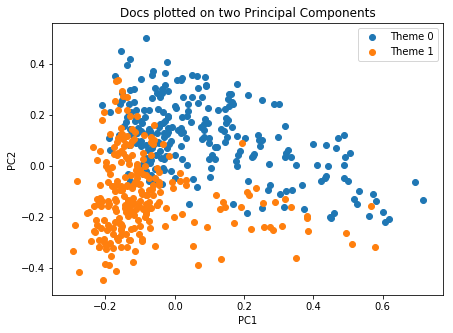

```python
plot_lda(abstracts, abstract_topics, clusters)
```

Below shows the most important words per theme. One is clearly about networks, while the the other has something to do with time.

```python
display(themes_lda(vect, lda).head(10))
```

|  | Theme 0 | Theme 1 |
| --- | --- | --- |
| 0 | network | problem |
| 1 | networks | time |
| 2 | learning | function |
| 3 | data | model |
| 4 | methods | analysis |
| 5 | models | order |
| 6 | method | algorithm |
| 7 | based | problems |
| 8 | approach | number |
| 9 | model | study |

The first two sentences of the top five abstracts for each of the two clusters are shown below.

```python
# First five abstracts in Topics
for i in range(clusters):
    theme = np.argsort(abstract_topics[:, i])[::-1]
    print("Theme", i)
    print("=====================")
    for i in theme[:5]:
        print(i,".".join(abstracts[i].split(".")[:2])+"\n")
```

```
Theme 0
=====================
171 accurate medical image segmentation is essential for diagnosis, surgical planning and many other applications. convolutional neural networks (cnns) have become the state-of-the-art automatic segmentation methods

327 existing learning-based atmospheric particle-removal approaches such as those used for rainy and hazy images are designed with strong assumptions regarding spatial frequency, trajectory, and translucency. however, the removal of snow particles is more complicated because it possess the additiona…

151 spectral clustering (sc) is one of the most widely used methods for data clustering. it first finds a low-dimensonal embedding $u$ of data by computing the eigenvectors of the normalized laplacian matrix, and then performs k-means on $u^\top$ to get the final clustering result

166 image captioning has been recently gaining a lot of attention thanks to the impressive achievements shown by deep captioning architectures, which combine convolutional neural networks to extract image representations, and recurrent neural networks to generate the corresponding captions. at the s…

73 generating emotional language is a key step towards building empathetic natural language processing agents. however, a major challenge for this line of research is the lack of large-scale labeled training data, and previous studies are limited to only small sets of human annotated sentiment label…

Theme 1
=====================
483 we develop a complete analysis of a general entry-exit-scrapping model. in particular, we consider an investment project that operates within a random environment and yields a payoff rate that is a function of a stochastic economic indicator such as the price of or the demand for the project's o…

162 in this paper we study continuous-time stochastic control problems with both monotone and classical controls motivated by the so-called public good contribution problem. that is the problem of n economic agents aiming to maximize their expected utility allocating initial wealth over a given time…

46 the article continues the study of the 'regular' arrangement of a collection of sets near a point in their intersection. such regular intersection or, in other words, transversality properties are crucial for the validity of qualification conditions in optimisation as well as subdifferential, nor…

379 temporal inhomogeneities observed in various natural and social phenomena have often been characterized in terms of scaling behaviors in the autocorrelation function with a decaying exponent $\gamma$, the interevent time distribution with a power-law exponent $\alpha$, and the burst size distrib…

256 in several multiobjective decision problems pairwise comparison matrices (pcm) are applied to evaluate the decision variants. the problem that arises very often is the inconsistency of a given pcm
```

## Results

The goal of this paper is to cluster abstracts and find common themes per cluster. Two models were used to cluster abstracts, namely k Means and Latent Dirichlet Allocation (LDA). Principal component analysis was performed to find the three axes or components that capture the most information. The data points, colored per cluster, were then plotted or projected on the top three principal components (3D plot) and top two principal components (2D plot). The most important words per cluster, which may indicate the themes, were also determined.

Based on the charts, k Means clustering was able to form clear boundaries between clusters for two clusters or three clusters. Beyond this, overlaps between clusters form. This means that two or three clusters is preferrable to distinguish the groups clearly. When three clusters were used for LDA however, two clusters clearly overlap. For LDA, two clusters was found to clearly separate abstracts. The table below shows the top words in each theme for each clustering method.

[output not shown]

Although k Means was able to generate two or three separate clusters, as projected on the principal components, the clusters are more difficult to interpret and some top words overlap. For k=3 we can infer that one cluster is about time-related problems, but the other two clusters are more vague. LDA, on the other hand was able to identify networks as a clear theme, and the other is about time, similar to what k means identified.

We have shown that both k Means and LDA can be used to cluster technical paper abstracts. The two methods were both able to identify the same theme about problem, time, and function. In general, LDA was able to show more distinguishable themes.

## References and Acknowledgements

Data from AIM Access Lab Team.